# Lab 07 Activity

Author

Published

Invalid Date

### Activity Objectives:

- Bayesian *t*-tests
- Check MCMC diagnostics

### Instructions:

- Fill in the code chunks
- Render the Quarto document and submit both the `.qmd` and `.html` file on Canvas

## Activity

### 1) If you’d like to load packages with `library()`, please do so in this block.

```r
library(tidyverse)
library(rstanarm)
```

### The United States Department of Agriculture released market prices for **pumpkins** in 13 cities in the United States from September 24, 2016 to September 30, 2017. The `pumpkin-prices-data.csv` file, which you can access at contains these prices from the Atlanta data file. You can read more about the data here: https://www.kaggle.com/datasets/usda/a-year-of-pumpkin-prices/data (but please use the version I added to our GitHub for this assignment).

The `price` variable contains the price sold at per 1,000 pounds of pumpkins. The `variety` variable contains the type of pumpkin: `HOWDEN TYPE` is the classic Jack-O-Lantern style pumpkin, and `PIE TYPE` is the type used for pumpkin pies! Your task is to examine if there are differences in market price between Howden Type and Pie Type pumpkins in the Bayesian framework.

First, read the data in and use a few functions to explore the data. Convert `variety` to a factor, and use the factor version for the rest of the analysis.

```r
d <- read_csv(here::here("lab", "data", "lab_07", "pumpkin_prices_data.csv"))
d$variety <- factor(d$variety)
```

### Conduct a Bayesian *t*-test using `stan_glm()` from the `rstanarm` R package to address this question, in the following steps:

#### How many parameters will you be estimating with this model, and what are they?

Three: $\beta_0$ is the overall intercept of pumpkin price at the reference group of Howden Type. $\beta_1$ is the difference in price between the Howden Type and the Pie Type. $\sigma$ is the remaining variance in price after accounting for variety.

#### Obtain the results of the *t*-test, and display the results. Provide a brief interpretation of each parameter.

```r
pumpkin_test <- stan_glm(price ~ variety, data = d, family = "gaussian")
summary(pumpkin_test)
```

```
Model Info:
 function:     stan_glm
 family:       gaussian [identity]
 formula:      price ~ variety
 algorithm:    sampling
 sample:       4000 (posterior sample size)
 priors:       see help('prior_summary')
 observations: 52
 predictors:   2

Estimates:
                  mean   sd    10%   50%   90%
(Intercept)     148.6    5.5 141.4 148.6 155.6
varietyPIE TYPE  31.5    9.8  19.0  31.6  43.8
sigma            33.7    3.5  29.5  33.4  38.3

Fit Diagnostics:
           mean   sd    10%   50%   90%
mean_PPD 158.8    6.5 150.4 158.8 167.3

The mean_ppd is the sample average posterior predictive distribution of the outcome variable (for details see help('summary.stanreg')).

MCMC diagnostics
                mcse Rhat n_eff
(Intercept)     0.1  1.0  3756
varietyPIE TYPE 0.2  1.0  3800
sigma           0.1  1.0  3041
mean_PPD        0.1  1.0  3645
log-posterior   0.0  1.0  1500

For each parameter, mcse is Monte Carlo standard error, n_eff is a crude measure of effective sample size, and Rhat is the potential scale reduction factor on split chains (at convergence Rhat=1).
```

#### Perform diagnostic checks of the model. Include, and comment on, the $\hat{R}$ values, the effective sample size, trace plots, and if there were any warnings from the sampler or not. Overall, how does it seem the sampler performed?

```r
summary(pumpkin_test)[, "Rhat"]
```

```
    (Intercept) varietyPIE TYPE           sigma        mean_PPD   log-posterior
      1.0013347       1.0008287       0.9995583       1.0004997       1.0023642
```

```r
summary(pumpkin_test)[, "n_eff"]
```

```
    (Intercept) varietyPIE TYPE           sigma        mean_PPD   log-posterior
           3756            3800            3041            3645            1500
```

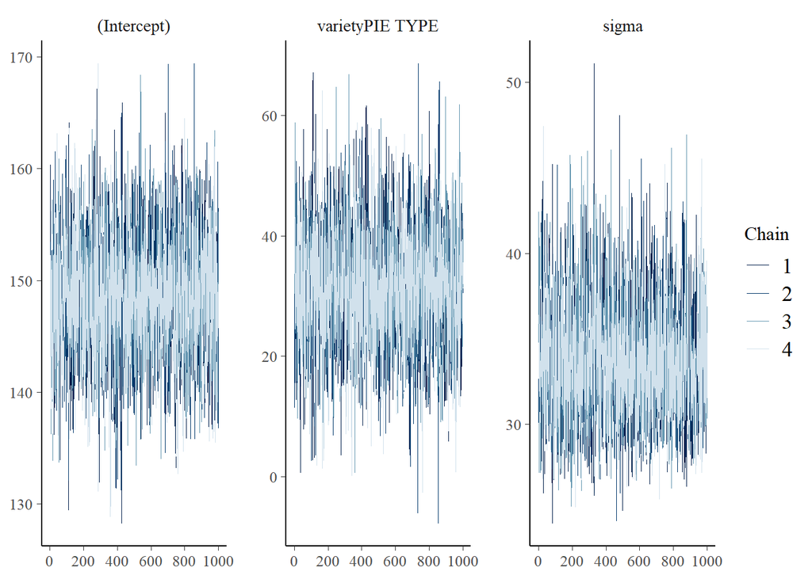

```r
bayesplot::mcmc_trace(pumpkin_test)
```

#### Calculate an Equal-Tailed Interval, and interpret it.

```r
posterior_interval(pumpkin_test)
```

```
                       5%       95%
(Intercept)     139.44782 157.65815
varietyPIE TYPE  15.21470  47.52657
sigma            28.55176  39.75205
```

#### Calculate an Highest Density Posterior Interval, and interpret it.

```r
bayestestR::hdi(pumpkin_test, component = "all")
```

```
Highest Density Interval

Parameter       |          95% HDI
----------------------------------
(Intercept)     | [138.09, 159.63]
varietyPIE TYPE | [ 12.70,  50.76]

# Fixed effects (sigma)

Parameter |          95% HDI
----------------------------
sigma     | [ 27.67,  40.95]
```